Exported from [`analysis/Whole_Genome_prior_estimation.ipynb`](http://github.com/hsun3163/jnbinder/blob/93314c88684ab4704a5db1f03c434d85b038a8f8/analysis/Whole_Genome_prior_estimation.ipynb) committed by Gao Wang on Wed May 5 20:26:26 2021 [revision 1, 93314c8](http://github.com/hsun3163/jnbinder/commit/93314c88684ab4704a5db1f03c434d85b038a8f8)

# Whole Genome prior estimation

This note book document the steps to generate mixture priors and the analysis of its result

# Steps

## Conduct univariate analysis for each genes,for each tissues, using all the SNPs

```r
nohup sos run ~/GIT/neuro-twas/Workflow/susie-wgs-prior.ipynb susie  \
  --molecular-pheno  /home/hs3163/Project/Rosmap/data/gene_exp/AC/geneTpmResidualsAgeGenderAdj_rename.txt  \
  --wd /home/hs3163/Project/Genome_prior/AC \
  --genotype_list /home/hs3163/Project/Rosmap/data/Rosmap_wgs_genotype_list.txt \
  --region_list /home/hs3163/Project/Rosmap/data/gene_exp/AC/geneTpmResidualsAgeGenderAdj_rename_region_list.txt \
  --region_name 1 \
  --data_start 2 \
  --window 500000 \
  --container /mnt/mfs/statgen/containers/twas_latest.sif \
  --job_size 1\
  -J 50 -q csg -c /mnt/mfs/statgen/pbs_template/csg.yml &
```

```r
nohup sos run ~/GIT/neuro-twas/Workflow/susie-wgs-prior.ipynb susie  \
  --molecular-pheno  /home/hs3163/Project/Rosmap/data/gene_exp/PCC/geneTpmResidualsAgeGenderAdj_rename.txt  \
  --wd /home/hs3163/Project/Genome_prior/PCC \
  --genotype_list /home/hs3163/Project/Rosmap/data/Rosmap_wgs_genotype_list.txt \
  --region_list /home/hs3163/Project/Rosmap/data/gene_exp/PCC/geneTpmResidualsAgeGenderAdj_rename_region_list.txt \
  --region_name 1 \
  --data_start 2 \
  --window 500000 \
  --container /mnt/mfs/statgen/containers/twas_latest.sif \
  --job_size 1\
  -J 50 -q csg -c /mnt/mfs/statgen/pbs_template/csg.yml &
```

```r
nohup sos run ~/GIT/neuro-twas/Workflow/susie-wgs-prior.ipynb susie  \
  --molecular-pheno  /home/hs3163/Project/Rosmap/data/gene_exp/DLPFC/geneTpmResidualsAgeGenderAdj_rename.txt  \
  --wd /home/hs3163/Project/Genome_prior/DLPFC \
  --genotype_list /home/hs3163/Project/Rosmap/data/Rosmap_wgs_genotype_list.txt \
  --region_list /home/hs3163/Project/Rosmap/data/gene_exp/DLPFC/geneTpmResidualsAgeGenderAdj_rename_region_list.txt \
  --region_name 1 \
  --data_start 2 \
  --window 500000 \
  --container /mnt/mfs/statgen/containers/twas_latest.sif \
  --job_size 1\
  -J 50 -q csg -c /mnt/mfs/statgen/pbs_template/csg.yml &
```

```r
nohup sos run ~/GIT/neuro-twas/Workflow/susie-wgs-prior.ipynb susie  \
  --molecular-pheno  /home/hs3163/Project/Rosmap/data/gene_exp/AC/geneTpmResidualsAgeGenderAdj_rename.txt  \
  --wd /home/hs3163/Project/Genome_prior/AC \
  --genotype_list /home/hs3163/Project/Rosmap/data/Rosmap_wgs_genotype_list.txt \
  --region_list  ~/sos/fifth/cac_bf \
  --region_name 1 \
  --data_start 2 \
  --window 500000 \
  --container /mnt/mfs/statgen/containers/twas_latest.sif \
  --job_size 1\
  -J 50 -q csg -c ~/GIT/neuro-twas/template/csg.yml -s build &
```

```r
nohup sos run ~/GIT/neuro-twas/Workflow/susie-wgs-prior.ipynb susie  \
  --molecular-pheno  /home/hs3163/Project/Rosmap/data/gene_exp/PCC/geneTpmResidualsAgeGenderAdj_rename.txt  \
  --wd /home/hs3163/Project/Genome_prior/PCC \
  --genotype_list /home/hs3163/Project/Rosmap/data/Rosmap_wgs_genotype_list.txt \
  --region_list ~/sos/fifth/cac_bf \
  --region_name 1 \
  --data_start 2 \
  --window 500000 \
  --container /mnt/mfs/statgen/containers/twas_latest.sif \
  --job_size 1\
  -J 50 -q csg -c ~/GIT/neuro-twas/template/csg.yml -s build &
```

```r
nohup sos run ~/GIT/neuro-twas/Workflow/susie-wgs-prior.ipynb susie  \
  --molecular-pheno  /home/hs3163/Project/Rosmap/data/gene_exp/DLPFC/geneTpmResidualsAgeGenderAdj_rename.txt  \
  --wd /home/hs3163/Project/Genome_prior/DLPFC \
  --genotype_list /home/hs3163/Project/Rosmap/data/Rosmap_wgs_genotype_list.txt \
  --region_list ~/sos/fifth/cac_bf \
  --region_name 1 \
  --data_start 2 \
  --window 500000 \
  --container /mnt/mfs/statgen/containers/twas_latest.sif \
  --job_size 1\
  -J 50 -q csg -c ~/GIT/neuro-twas/template/csg.yml -s build &
```

```r
/mnt/mfs/statgen/neuro-twas/cac
```

### Compute Mixture prior via flash and then estimate the weights of the prior with UDR and TEEM

effect model = exchangable Z score

constraint for flash: both postivitiy and non-constraint result are reported.

In neither case is the bhat or zscore centered.

```r
nohup sos run ~/GIT/neuro-twas/Workflow/wg_prior_genome.ipynb mm_prior \
--molecular_pheno_dir /home/hs3163/Project/Genome_prior/data/molc_dir    \
--rds_list /home/hs3163/Project/Genome_prior/data/rds_list  \
--wd   /home/hs3163/Project/Genome_prior/mixture_prior \
--name "geneTpmResidualsAgeGenderAdj_rename" \
--container /mnt/mfs/statgen/containers/twas_latest.sif \
--constraint "Both" \
-J 10 -q csg -c /mnt/mfs/statgen/pbs_template/csg.yml -s build &
```

### Conduct MV susie with mixture prior with both teem and udr of risk locus

Imputed X, complete case Y

```r
# Teem
nohup sos run ~/GIT/neuro-twas/Workflow/mv_susie.ipynb mv_susie_cv    \
--molecular_pheno_dir "/home/hs3163/Project/Alz/multi/molecular_phenotype_list"   \
--region_list "/home/hs3163/Project/Alz/multi/mv_susie_gene_list.txt"  \
--wd "/home/hs3163/Project/Alz/multi_mp"  \
--name_prefix "geneTpmResidualsAgeGenderAdj_rename"  \
--container /mnt/mfs/statgen/containers/twas_latest.sif --impute TRUE  --job_size 1 \
--cv_times 100  \
--mixture_prior '~/Project/Genome_prior/merge/output/geneTpmResidualsAgeGenderAdj_rename.Both.flash.FL_PC3.teem.UD_ED.rds' \
-J 50 -q csg -c ~/GIT/neuro-twas/template/csg.yml -s build &


# UDR Prior
nohup sos run ~/GIT/neuro-twas/Workflow/mv_susie.ipynb mv_susie_cv    \
--molecular_pheno_dir "/home/hs3163/Project/Alz/multi/molecular_phenotype_list"   \
--region_list "/home/hs3163/Project/Alz/multi/mv_susie_gene_list.txt"  \
--wd "/home/hs3163/Project/Alz/multi_mp_2"  \
--name_prefix "geneTpmResidualsAgeGenderAdj_rename"  \
--container /mnt/mfs/statgen/containers/twas_latest.sif --impute TRUE  --job_size 1 \
--cv_times 100  \
--mixture_prior '~/Project/Genome_prior/merge/output/geneTpmResidualsAgeGenderAdj_rename.Both.flash.FL_PC3.ed.UD_ED.rds'  -J 6 -q csg -c /mnt/mfs/statgen/pbs_template/csg.yml -s build &
```

### Conduct MV susie with mixture prior with both teem and udr of all genes

Imputed X, complete case Y

# Analysis

## Visualization of Mixuture priors

```r
# Read Data
TEEM = readRDS('~/Project/Genome_prior/merge/output/geneTpmResidualsAgeGenderAdj_rename.Both.flash.FL_PC3.teem.UD_ED.rds')
UDR = readRDS('~/Project/Genome_prior/merge/output/geneTpmResidualsAgeGenderAdj_rename.Both.flash.FL_PC3.ed.UD_ED.rds')
Ori = readRDS('~/Project/Genome_prior/merge/output/geneTpmResidualsAgeGenderAdj_rename.Both.flash.rds')
```

```r
library(dplyr)
library(ggplot2)
library(tibble)
library(readr)
library(purrr)
library(tidyr)
```

### Component with weights

The component with strongest weight is tflash in both case, the second strongest is pca_2 in teem, XX in UDR

A matrix: 4 × 1 of type dbl

| teem_logik | -125523.5 |
| --- | --- |
| length | 1.0 |
| udr_logik | -126149.8 |
| length | 1.0 |

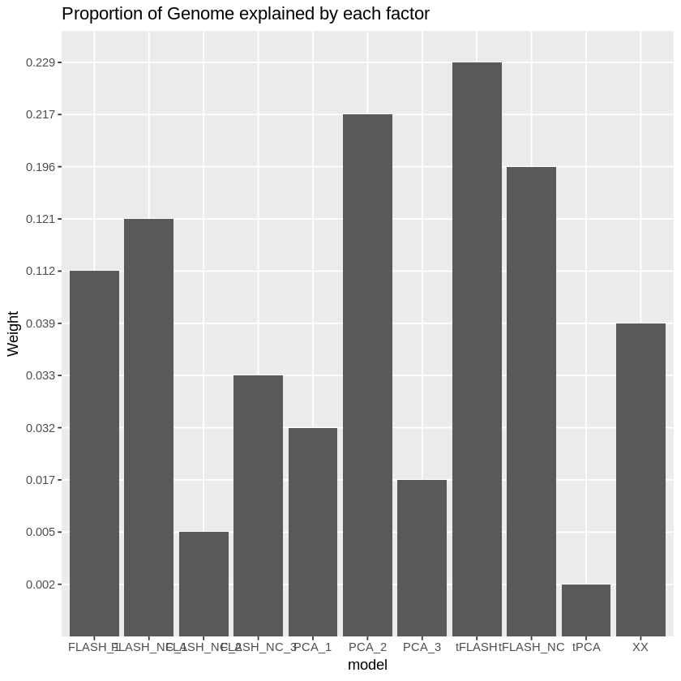

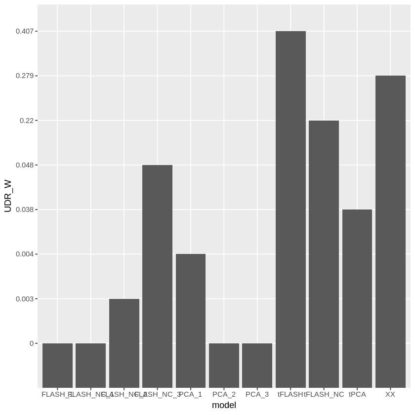

```r
rbind(
teem_logik = TEEM$loglik[length(TEEM$loglik)],
length = length(TEEM$loglik),
udr_logik = UDR$loglik[length(UDR$loglik)],
length = length(UDR$loglik)
    )
cbind(model = names(TEEM$U), Teem_W = TEEM$w%>%round(3), UDR_W = UDR$w%>%round(3))%>%as_tibble%>%ggplot(aes(x = model))+geom_col(aes(x = model,y = Teem_W ))+ylab("Weight")+ggtitle("Proportion of Genome explained by each factor")
cbind(model = names(TEEM$U), Teem_W = TEEM$w%>%round(3), UDR_W = UDR$w%>%round(3))%>%as_tibble%>%ggplot(aes(x = model))+geom_col(aes(x = model,y = UDR_W ))
```

```r
tol = 1E-15
names(UDR$U)[which(UDR$w<tol)]
names(TEEM$U)[which(TEEM$w<tol)]
```

```
Error in eval(expr, envir, enclos): object 'UDR' not found
Traceback:
```

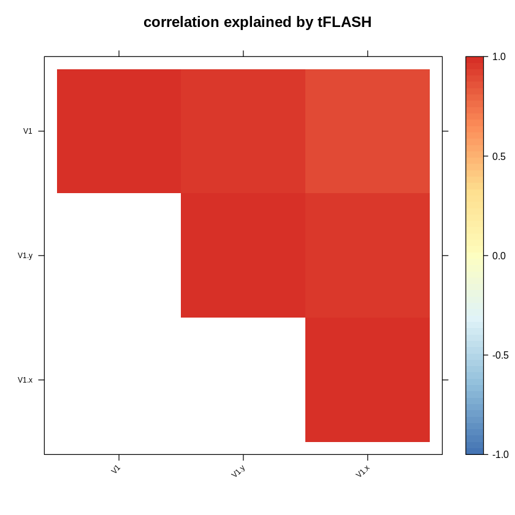

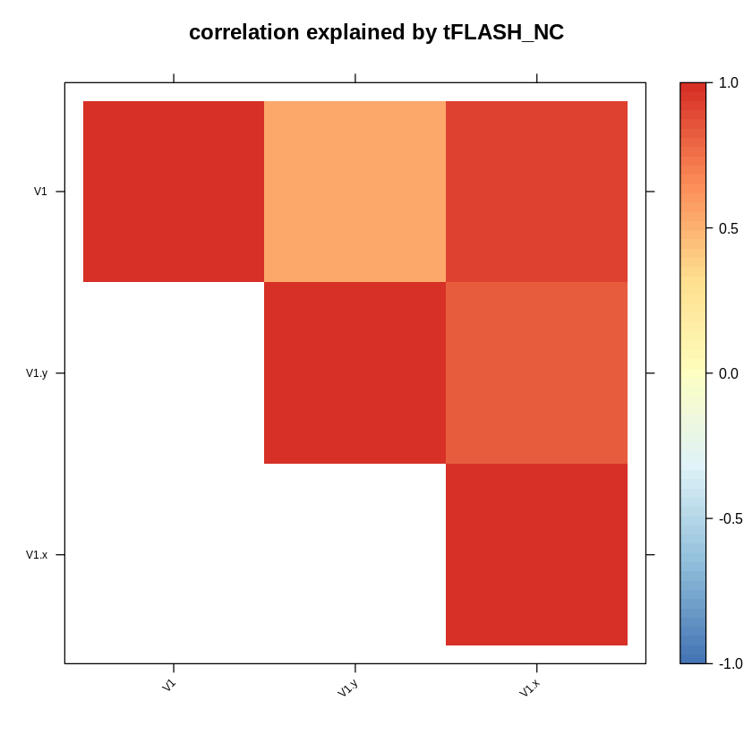

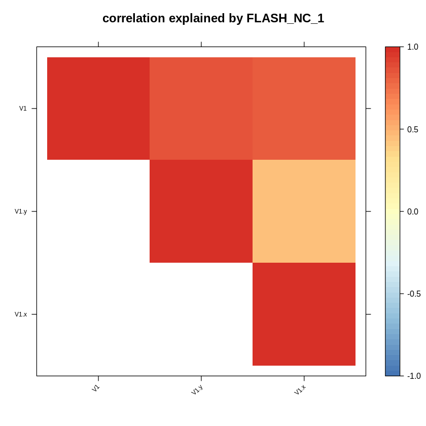

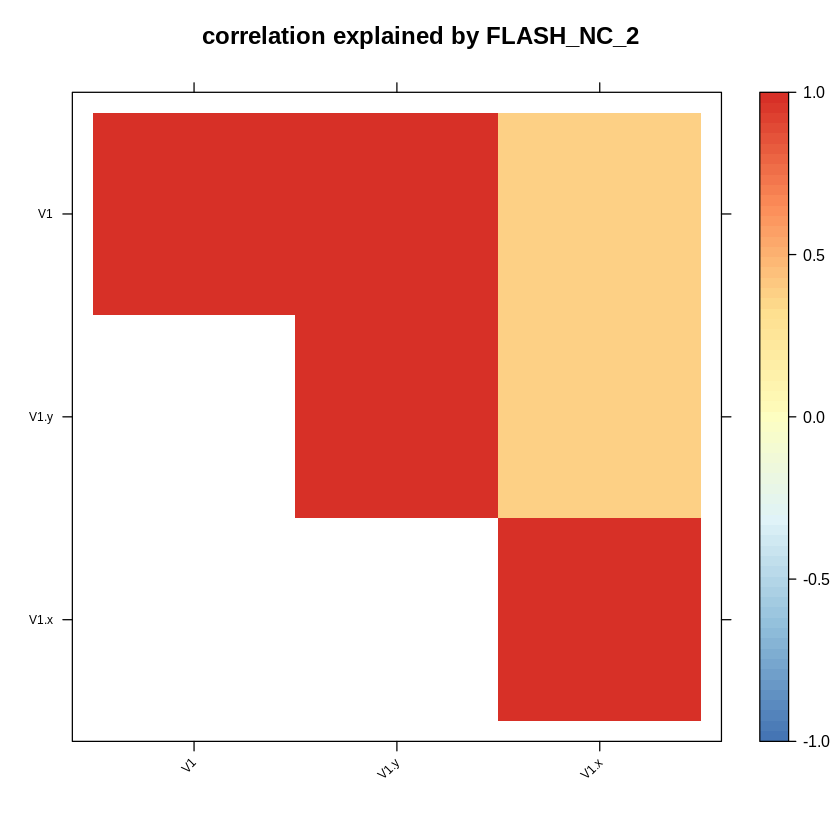

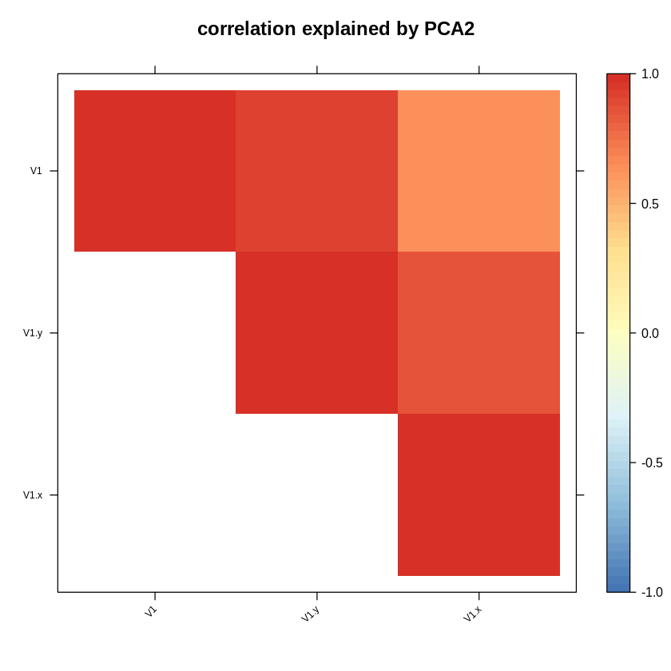

```r
plot_sharing = function(X,title) {
clrs <- colorRampPalette(rev(c("#D73027","#FC8D59","#FEE090","#FFFFBF",
                               "#E0F3F8","#91BFDB","#4575B4")))(64)
lat <- cov2cor(X)
lat[lower.tri(lat)] <- NA
n <- nrow(lat)
print(lattice::levelplot(lat[n:1,],col.regions = clrs,xlab = "",ylab = "",
                colorkey = TRUE,at = seq(-1,1,length.out = 64),
                scales = list(cex = 0.6,x = list(rot = 45)), main = title)
    )
}
plot_sharing(TEEM$U$tFLASH,"correlation explained by tFLASH")
plot_sharing(TEEM$U$tFLASH_NC,"correlation explained by tFLASH_NC")
plot_sharing(TEEM$U$FLASH_NC_1,"correlation explained by FLASH_NC_1")
plot_sharing(TEEM$U$FLASH_NC_2,"correlation explained by FLASH_NC_2")
plot_sharing(TEEM$U$PCA_2,"correlation explained by PCA2")
```

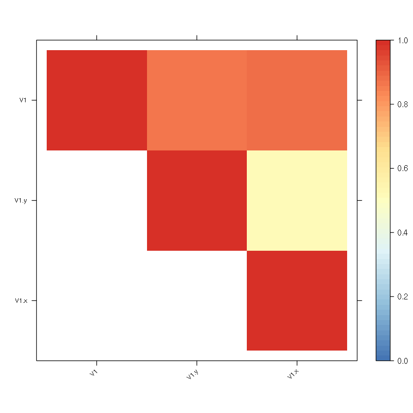

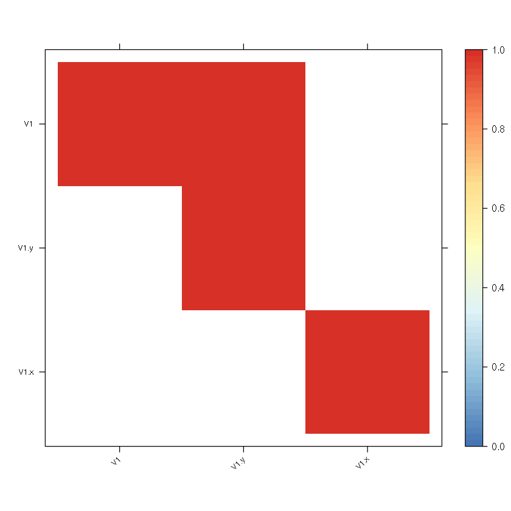

A matrix: 3 × 3 of type dbl

|  | V1.x | V1.y | V1 |
| --- | --- | --- | --- |
| V1.x | 13.229994 | 5.559956 | 4.339570 |
| V1.y | 5.559956 | 8.727967 | 3.495610 |
| V1 | 4.339570 | 3.495610 | 1.860764 |

A matrix: 3 × 3 of type dbl

|  | V1.x | V1.y | V1 |
| --- | --- | --- | --- |
| V1.x | 291.7370 | 241.4582 | 298.5810 |
| V1.y | 241.4582 | 199.8446 | 247.1227 |
| V1 | 298.5810 | 247.1227 | 305.5856 |

A matrix: 3 × 3 of type dbl

| V1.x | V1.y | V1 |
| --- | --- | --- |
| 0.3659672 | 0.3028953 | 0.3745526 |
| 0.3028953 | 0.2506934 | 0.3100011 |
| 0.3745526 | 0.3100011 | 0.3833394 |

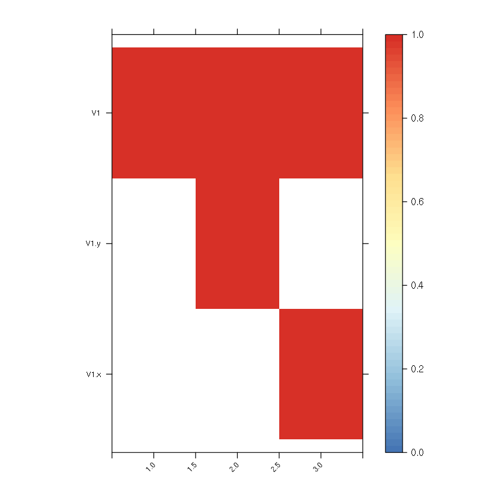

```r
plot_sharing(TEEM$U$FLASH_1)
plot_sharing(UDR$U$FLASH_1)
plot_sharing(Ori$FLASH_1)
TEEM$U$FLASH_1
UDR$U$FLASH_1
Ori$FLASH_1
```

```r
cov2cor(TEEM$U$FLASH_NC_1)
cov2cor(TEEM$U$FLASH_NC_2)
cov2cor(TEEM$U$FLASH_NC_3)
cov2cor(TEEM$U$FLASH_1)
```

A matrix: 3 × 3 of type dbl

|  | V1.x | V1.y | V1 |
| --- | --- | --- | --- |
| V1.x | 1.0000000 | 0.4373365 | 0.8229308 |
| V1.y | 0.4373365 | 1.0000000 | 0.8708263 |
| V1 | 0.8229308 | 0.8708263 | 1.0000000 |

A matrix: 3 × 3 of type dbl

|  | V1.x | V1.y | V1 |
| --- | --- | --- | --- |
| V1.x | 1.0000000 | 0.3873686 | 0.3958910 |
| V1.y | 0.3873686 | 1.0000000 | 0.9999571 |
| V1 | 0.3958910 | 0.9999571 | 1.0000000 |

A matrix: 3 × 3 of type dbl

|  | V1.x | V1.y | V1 |
| --- | --- | --- | --- |
| V1.x | 1 | 1 | 1 |
| V1.y | 1 | 1 | 1 |
| V1 | 1 | 1 | 1 |

A matrix: 3 × 3 of type dbl

|  | V1.x | V1.y | V1 |
| --- | --- | --- | --- |
| V1.x | 1.0000000 | 0.5174102 | 0.8746238 |
| V1.y | 0.5174102 | 1.0000000 | 0.8674027 |
| V1 | 0.8746238 | 0.8674027 | 1.0000000 |

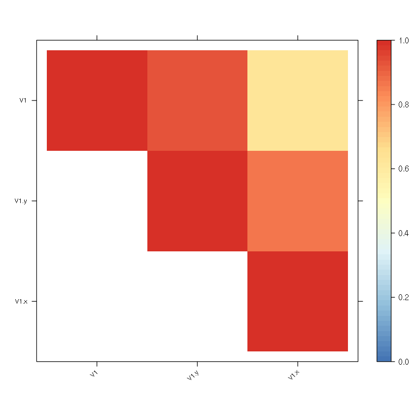

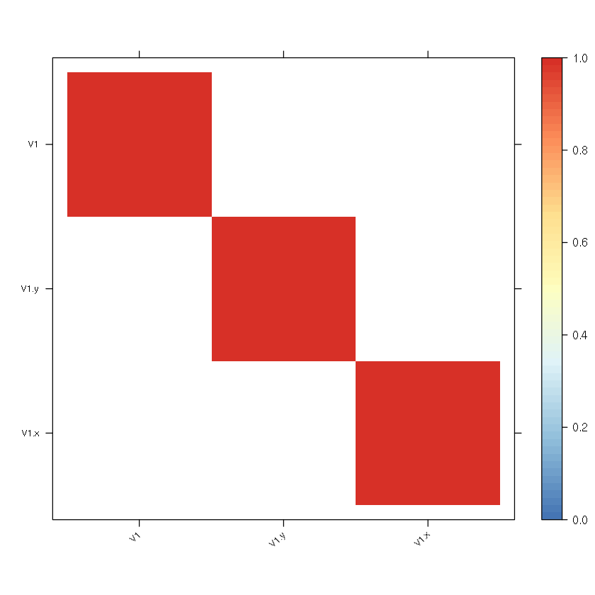

```r
plot_sharing(TEEM$U$PCA_2)
plot_sharing(UDR$U$PCA_2)
```

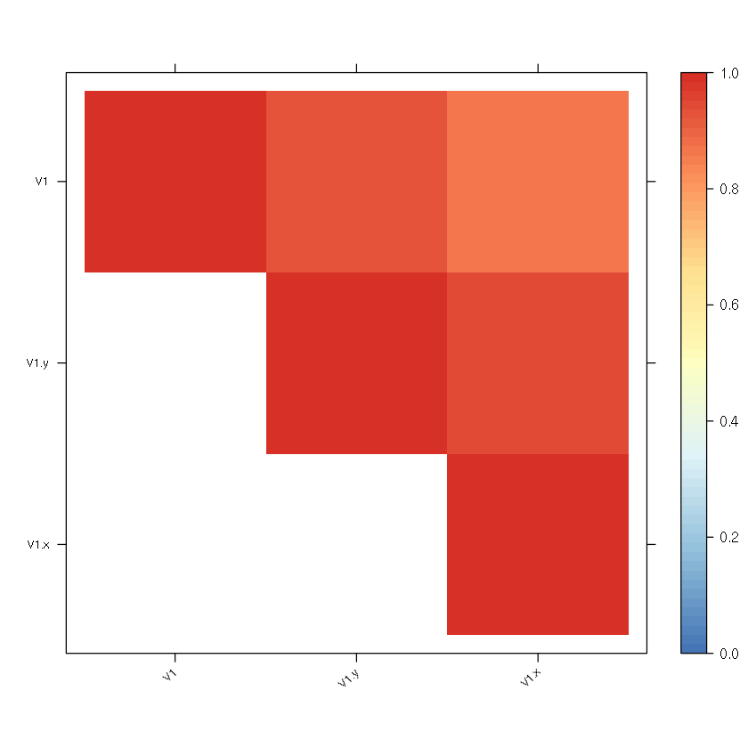

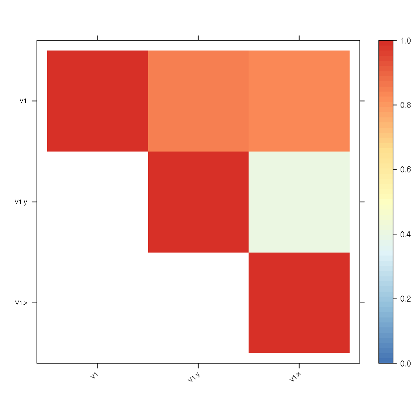

```r
plot_sharing(TEEM$U$XX)
plot_sharing(UDR$U$XX)
```

```r
UDR$U$XX%>%cov2cor
TEEM$U$XX%>%cov2cor
```

A matrix: 3 × 3 of type dbl

|  | V1.x | V1.y | V1 |
| --- | --- | --- | --- |
| V1.x | 1.0000000 | 0.4058815 | 0.8330067 |
| V1.y | 0.4058815 | 1.0000000 | 0.8413912 |
| V1 | 0.8330067 | 0.8413912 | 1.0000000 |

A matrix: 3 × 3 of type dbl

|  | V1.x | V1.y | V1 |
| --- | --- | --- | --- |
| V1.x | 1.0000000 | 0.9422622 | 0.8650419 |
| V1.y | 0.9422622 | 1.0000000 | 0.9244859 |
| V1 | 0.8650419 | 0.9244859 | 1.0000000 |

## Accuracy of the CV results

```r
# Load data
env_teem = attach("/home/hs3163/Project/Alz/multi_mp/mv_cv.RData")
env_udr = attach("/home/hs3163/Project/Alz/multi_mp_2/mv_cv.RData")
```

### TEEM

```r
# All three tissues
```

A tibble: 1 × 3

| mean(n_of_cs) <dbl> | mean(total_cs_size) <dbl> | mean(mean_cs_size) <dbl> |
| --- | --- | --- |
| 0.4556962 | 7.21519 | NaN |

57

```
Warning message:
“Removed 10 rows containing non-finite values (stat_bin).”

Warning message:
“Removed 11 rows containing non-finite values (stat_bin).”
```

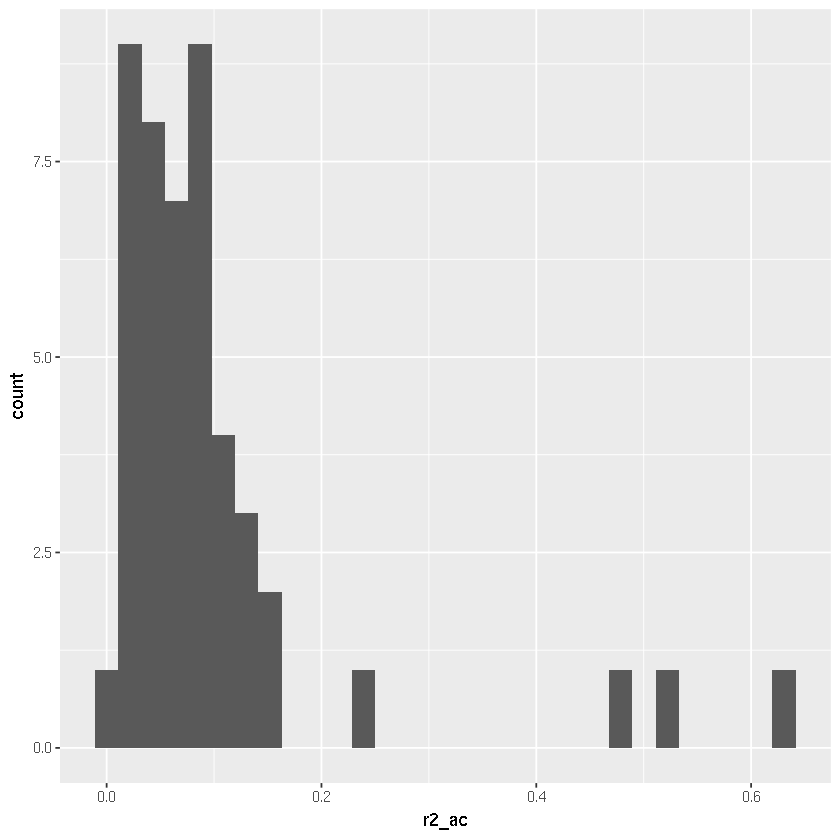

```
Warning message:
“Removed 11 rows containing non-finite values (stat_bin).”
```

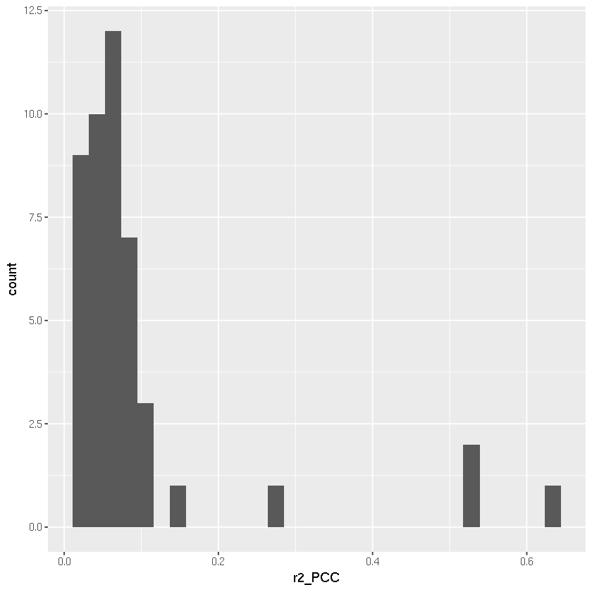

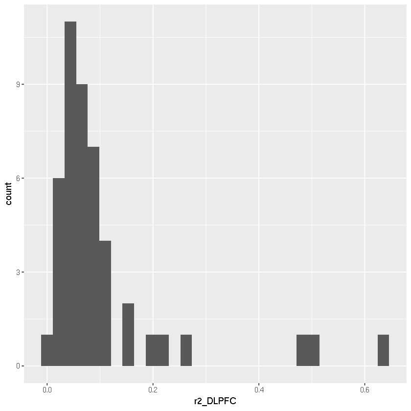

```r
data = env_teem$output
working = data%>%select(-path)
working = working%>%mutate(
  n_of_cs = map_dbl(model,~.x$sets$cs_index%>%length()),
  hsq_ac = map_dbl(model,~.x$hsq[1]),
  hsq_PCC = map_dbl(model,~.x$hsq[2]),
  hsq_DLPFC = map_dbl(model,~.x$hsq[3]),
  total_cs_size = map_dbl(model,(~.x$sets$cs%>%unlist()%>%length())),
  mean_cs_size = total_cs_size/n_of_cs
)
working%>%select(-env,-model
                )%>%summarise(mean(n_of_cs),mean(total_cs_size),mean(mean_cs_size))
nrow(working%>%filter(n_of_cs>0))
working = working%>%mutate(
  rmse_ac = map_dbl(model,~.x$rmse[1]),
  rmse_PCC = map_dbl(model,~.x$rmse[2]),
  rmse_DLPFC = map_dbl(model,~.x$rmse[3]),
  r2_ac = map_dbl(model,~.x$r2[1]),
  r2_PCC = map_dbl(model,~.x$r2[2]),
  r2_DLPFC = map_dbl(model,~.x$r2[3]),
  pval_ac = map_dbl(model,~.x$pval[1]),
  pval_PCC = map_dbl(model,~.x$pval[2]),
  pval_DLPFC = map_dbl(model,~.x$pval[3])
)
#working%>%filter(n_of_cs > 0)%>%select(ID,n_of_cs,rmse_ac,rmse_PCC,rmse_DLPFC,r2_ac,r2_PCC,r2_DLPFC)%>%arrange(-r2_DLPFC)
working%>%select(-env,-model
                )%>%filter(n_of_cs > 0)%>%ggplot(aes(x = r2_ac))+geom_histogram()
working%>%select(-env,-model
                )%>%filter(n_of_cs > 0)%>%ggplot(aes(x = r2_PCC))+geom_histogram()
working%>%select(-env,-model
                )%>%filter(n_of_cs > 0)%>%ggplot(aes(x = r2_DLPFC))+geom_histogram()
```

## UDR

A tibble: 1 × 3

| mean(n_of_cs) <dbl> | mean(total_cs_size) <dbl> | mean(mean_cs_size) <dbl> |
| --- | --- | --- |
| 0.4493671 | 6.841772 | NaN |

56

```
Warning message:
“Removed 11 rows containing non-finite values (stat_bin).”

Warning message:
“Removed 10 rows containing non-finite values (stat_bin).”
```

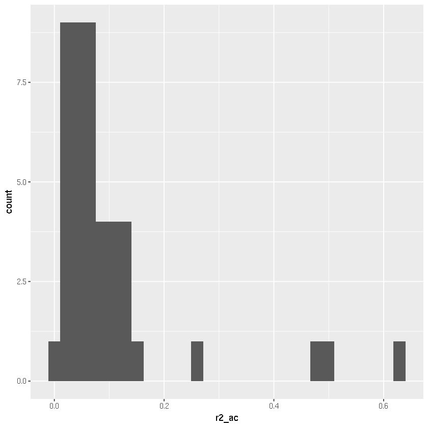

```
Warning message:
“Removed 7 rows containing non-finite values (stat_bin).”
```

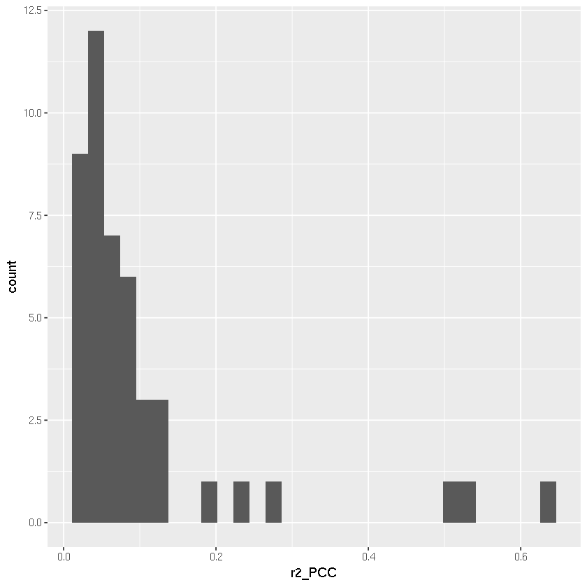

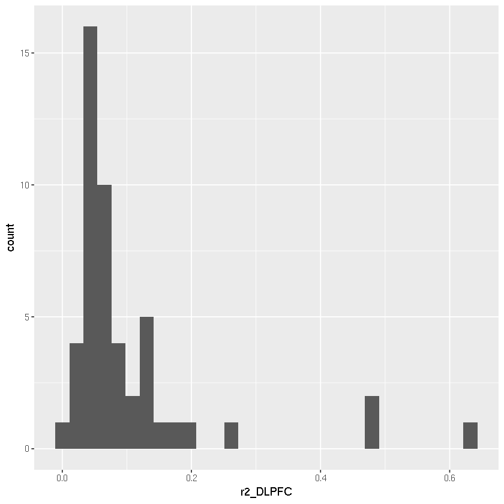

```r
# All three tissues
data = env_udr$output
working = data%>%select(-path)
working = working%>%mutate(
  n_of_cs = map_dbl(model,~.x$sets$cs_index%>%length()),
  hsq_ac = map_dbl(model,~.x$hsq[1]),
  hsq_PCC = map_dbl(model,~.x$hsq[2]),
  hsq_DLPFC = map_dbl(model,~.x$hsq[3]),
  total_cs_size = map_dbl(model,(~.x$sets$cs%>%unlist()%>%length())),
  mean_cs_size = total_cs_size/n_of_cs
)
working%>%select(-env,-model
                )%>%summarise(mean(n_of_cs),mean(total_cs_size),mean(mean_cs_size))
nrow(working%>%filter(n_of_cs>0))

working = working%>%mutate(
  rmse_ac = map_dbl(model,~.x$rmse[1]),
  rmse_PCC = map_dbl(model,~.x$rmse[2]),
  rmse_DLPFC = map_dbl(model,~.x$rmse[3]),
  r2_ac = map_dbl(model,~.x$r2[1]),
  r2_PCC = map_dbl(model,~.x$r2[2]),
  r2_DLPFC = map_dbl(model,~.x$r2[3]),
  pval_ac = map_dbl(model,~.x$pval[1]),
  pval_PCC = map_dbl(model,~.x$pval[2]),
  pval_DLPFC = map_dbl(model,~.x$pval[3])
)
#working%>%filter(n_of_cs > 0)%>%select(ID,n_of_cs,rmse_ac,rmse_PCC,rmse_DLPFC,r2_ac,r2_PCC,r2_DLPFC)%>%arrange(-r2_DLPFC)
working%>%select(-env,-model
                )%>%filter(n_of_cs > 0)%>%ggplot(aes(x = r2_ac))+geom_histogram()
working%>%select(-env,-model
                )%>%filter(n_of_cs > 0)%>%ggplot(aes(x = r2_PCC))+geom_histogram()
working%>%select(-env,-model
                )%>%filter(n_of_cs > 0)%>%ggplot(aes(x = r2_DLPFC))+geom_histogram()


vis = working%>%select(-env,-model
                )
```

```r
vis%>%filter(n_of_cs > 0)%>%arrange(-r2_ac)%>%select(ID,r2_ac,pval_ac,pval_PCC,pval_DLPFC)%>%filter(pval_DLPFC<0.05/158)
```

[output not shown]